# Motor Insurance Portfolio Analysis

Spanish Market | 2022–2024

Andy Tai

2026-05-21

## Contents

- 1. Portfolio Overview
- 2. Policyholder Characteristics and Claims Behaviour
- 3. Risk-Return Analysis
- 4. Deep-dive on Loss-making Portfolios
- 5. At-Risk Portfolio Sensitivity & Scenario Analysis
- 6. Conclusion

## 1. Portfolio Overview

### Policyholders are mostly of medium risk-appetite, with risk-averse and risk-tolerant segments on either side

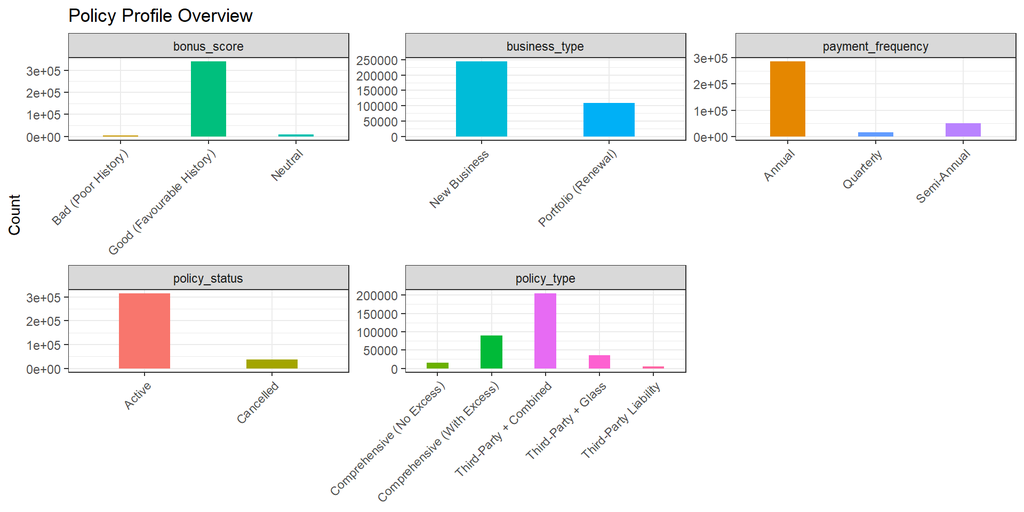

- The portfolio is heavily weighted towards policyholders with good claims history, annual payments and of “Third Party + Combined cover”.
- Most policies are active and new business is greater than renewals, a sign of a stable and growing book.

## 2. Policyholder Characteristics and Claims Behaviour

### Older drivers may be switching to lower-cost policies

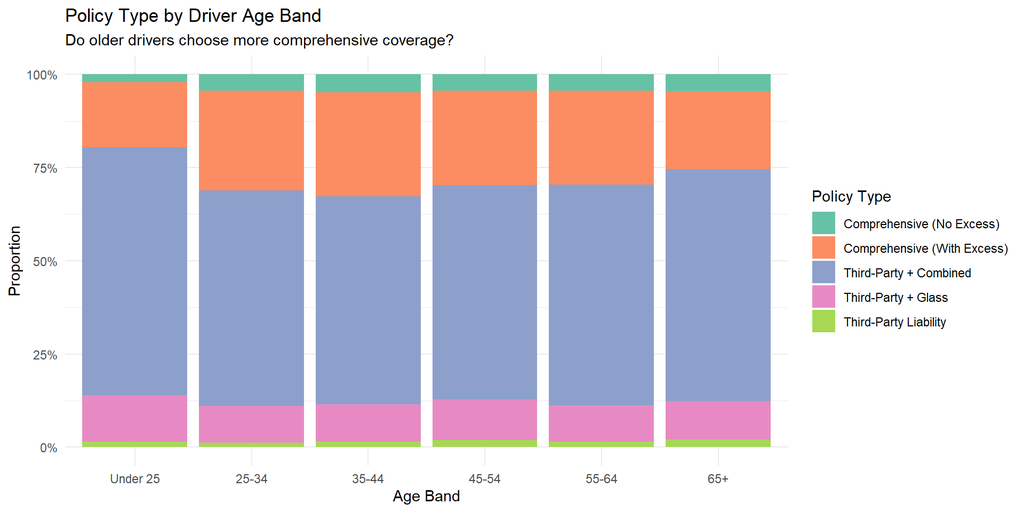

## 2. Policyholder Characteristics and Claims Behaviour

### Over time, insurer is paying out more in claims than it collects in premiums for ‘Comprehensive (No Excess)’ policy

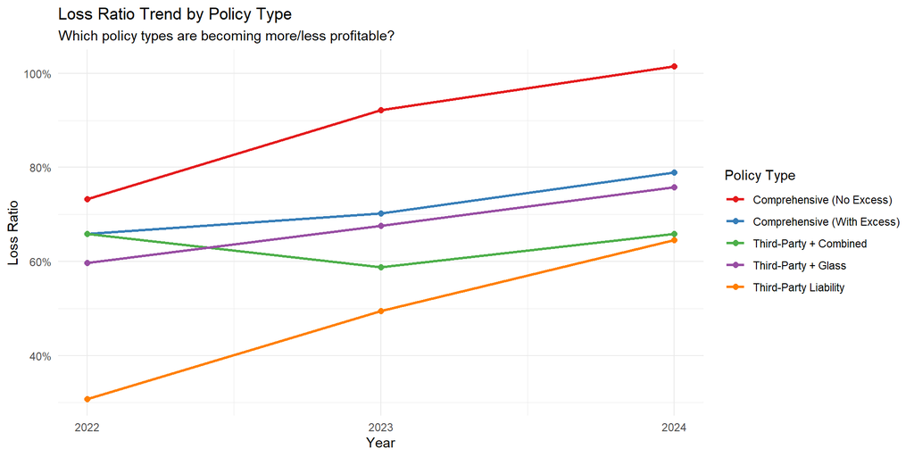

## 2. Policyholder Characteristics and Claims Behaviour

### Lack of driving experience correlates with higher claim frequency almost across all age-bands

[figure not shown]

- Less driving experience generally corresponds to higher claim frequency.
- Drivers aged 55–64 with ≤2 years of experience have the highest claim frequency (>90%).

## 3. Risk-Return Analysis

### Frequency-Severity Bubble Chart - profitability deterioration may be driven primarily by claims frequency

[interactive chart not shown]

- From 2022 to 2024, claim severity became more uniform across segments.
- Loss-making segments in 2024 are concentrated in high-frequency areas, suggesting profitability deterioration is driven mainly by claim frequency rather than severity.

## 3. Risk-Return Analysis

### Trend Changes - all three loss-making portfolios in 2024 belong to Comprehensive (No Excess) policy type

[interactive chart not shown]

- Profit margins declined across most segments, with three Comprehensive (No Excess) segments becoming loss-making by 2024, making it the portfolio’s most distressed product.
- The left panel shows these loss-making segments relative to median claim frequency and severity levels.

## 4. Deep-dive on Loss-making Portfolios

### Claim frequency - Property claims consistently record the highest frequency with rising trend

[figure not shown]

- Across all loss-making age bands, Property claims have the highest frequency and show a sharp increase, especially from 2023 to 2024.
- This suggests Property damage is the main driver of rising claim frequency in the Comprehensive (No Excess) portfolio.

## 4. Deep-dive on Loss-making Portfolio

### Claim severity - ‘Liability Injury’ and ‘Fire’ claims appeared to be the main claims driving cost pressures within the portfolio

[figure not shown]

- Liability Injury claims are the most severe for the 25–34 and 65+ groups, peaking in 2023 before declining in 2024.
- For the 35–44 group, Fire claims tripled from around €5,000 in 2022 to €15,000 in 2024, making them a growing severity concern.

## 4. Deep-dive on Loss-making Portfolios

### Driving experience - loss-making portfolio averages approximately 10 years less driving experience in 2022, narrowing to around 8 years by 2024

[interactive chart not shown]

Drivers in loss-making Comprehensive (No Excess) segments are consistently less experienced than those in profitable segments, averaging 8–10 fewer years of driving experience between 2022 and 2024.

## 4. Deep-dive on Loss-making Portfolios

### Age x Driving experience - The 35-44 age band deteriorates broadly in 2024 across all experience levels, suggesting a systemic issue beyond driving experience alone

[interactive chart not shown]

- Portfolio performance deteriorated from 2022 to 2024, with drivers aged 65+ remaining consistently high risk.
- The 35–44 group worsened most in 2024, with the under-2-years experience segment reaching a 376% loss ratio.

## 5. At-Risk Portfolio Sensivity & Scenario Analysis

### Sensivity Analysis - a mere 5% increase in claim frequency for the at risk segment can lead reduce profitability by €68.6K,highlighting the segment’s vulnerability to rising claims

[interactive chart not shown]

- The sensitivity analysis assesses how changes in claim frequency affect profitability, holding premiums constant.
- A 5% increase in claim frequency reduces At-Risk P&L by €68,600, highlighting the segment’s vulnerability to rising claims.
- At-Risk (70% ≤ LR < 100%) means that they are profitable today, but vulnerable to becoming loss-making if claims worsen.

## 5. At-Risk Portfolio Sensivity & Scenario Analysis

### Scenario Analysis - A combination of adverse shocks to policy volume, claim frequency, and claim severity can rapidly erode profitability, highlighting the portfolio’s exposure to black swan events.

[interactive chart not shown]

- The scenario analysis stress-tests the at-risk portfolio under Base, Best, and Worst Case assumptions.
- By applying shocks only to at-risk segments, it isolates their impact on segment and overall portfolio profitability.

## 6. Conclusion

### Losses is due to multiple factors, and profitability position can be sensitive to unforeseen events affecting the at-risk segment. Inventions may be necessary to mitigate this risk

- Portfolio is becoming more unprofitable over the 2022-2024 timeframe, with some age groups and policy types disproportionately responsible for the losses.
- Analysis demonstrates that unprofitability is not related to a single cause but rather a confluence of factors.
- The scenario analysis shows that without assistance the financial prognosis for the at-risk categories is likely to deteriorate.